# Intorduction

## Checking other fields

```python
housing.describe()
```

|  | longitude | latitude | housing_median_age | total_rooms | total_bedrooms | population | households | median_income | median_house_value |
| --- | --- | --- | --- | --- | --- | --- | --- | --- | --- |
| count | 20640.000000 | 20640.000000 | 20640.000000 | 20640.000000 | 20433.000000 | 20640.000000 | 20640.000000 | 20640.000000 | 20640.000000 |
| mean | -119.569704 | 35.631861 | 28.639486 | 2635.763081 | 537.870553 | 1425.476744 | 499.539680 | 3.870671 | 206855.816909 |
| std | 2.003532 | 2.135952 | 12.585558 | 2181.615252 | 421.385070 | 1132.462122 | 382.329753 | 1.899822 | 115395.615874 |
| min | -124.350000 | 32.540000 | 1.000000 | 2.000000 | 1.000000 | 3.000000 | 1.000000 | 0.499900 | 14999.000000 |
| 25% | -121.800000 | 33.930000 | 18.000000 | 1447.750000 | 296.000000 | 787.000000 | 280.000000 | 2.563400 | 119600.000000 |
| 50% | -118.490000 | 34.260000 | 29.000000 | 2127.000000 | 435.000000 | 1166.000000 | 409.000000 | 3.534800 | 179700.000000 |
| 75% | -118.010000 | 37.710000 | 37.000000 | 3148.000000 | 647.000000 | 1725.000000 | 605.000000 | 4.743250 | 264725.000000 |
| max | -114.310000 | 41.950000 | 52.000000 | 39320.000000 | 6445.000000 | 35682.000000 | 6082.000000 | 15.000100 | 500001.000000 |

```
array([[<matplotlib.axes._subplots.AxesSubplot object at 0x10f01d7b8>,
      dtype=object)
```

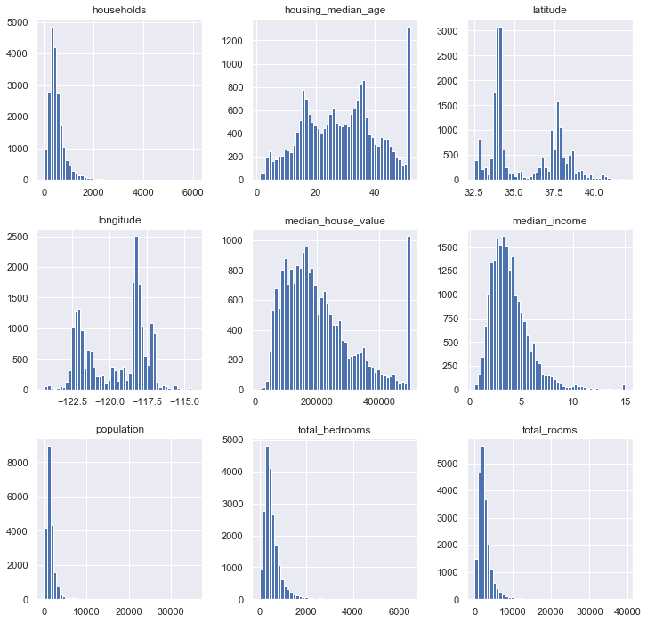

```python
# Plotting histograms for numerical features
housing.hist(bins=50)
```

## Notes

1. thedata has been scaled and capped at 15 (actually 15.0001) for higher medianincomes, and at 0.5 (actually 0.4999) for lower median incomes.
2. The housing median age and the median house value were also capped. The lattermay be a serious problem since it is your target attribute (your labels). The Machine Learning algorithms may learn that prices never go beyond that limit. Check with your client team (the team that will use the system’s output) to see if this is a problem or not. If they tell that they need precise predictions even beyond \$500,000, then you have mainly two options:
   1. Collect proper labels for the districts whose labels were capped.
   2. Remove those districts from the training set (and also from the test set, since your system should not be evaluated poorly if it predicts values beyond \$500,000).
3. The attributes have very different scales. Scalling will be required.
4. Finally, many histograms are tail heavy: they extend much farther to the right of the median than to the left. This may make it a bit harder for some Machine Learning algorithms to detect patterns. We will try transforming these attributes later on to have more bell-shaped distributions.

# Create test set

## Data snooping bias

Creating a test set that early is good to void *data snooping bias* where your brain might recognize patterns in the test set and start overfitting those patterns.

```python
train_set, test_set = train_test_split(housing, test_size=0.2, random_state=42)
print(len(train_set), "train +", len(test_set), "test")
```

```
16512 train + 4128 test
```

## Stratified sampling

The median income is a very important feature for predicting the median housing price. Thus, we will need statified sampling for the train test split.

Looking at the median_income histogram, most values are clustered around 2-5 but some go far beyond 6.

The following code creates an income category attribute by dividing the median income by 1.5 (to limit the number of income categories), and rounding up using ceil (to have discrete categories), and then merging all the categories greater than 5 into category 5:

```python
# creating income_cat column
housing['income_cat'] = np.ceil(housing['median_income'] / 1.5)
housing['income_cat'].where(housing['income_cat'] < 5, 5.0, inplace=True)
```

```python
# creating the split
split = StratifiedShuffleSplit(n_splits=1, test_size=0.2, random_state=42)
for train_index, test_index in split.split(housing, housing['income_cat']):
    strat_train_set = housing.loc[train_index]
    strat_test_set = housing.loc[test_index]
```

```python
# removing the income_cat folumn
for set in (strat_train_set, strat_test_set):
    set.drop(['income_cat'], axis=1, inplace=True)
```

# Data exploration

```python
# making a copy of the stratified training data
housing = strat_train_set.copy()
```

## Data visualization

### Geographical data

```
'c' argument looks like a single numeric RGB or RGBA sequence, which should be avoided as value-mapping will have precedence in case its length matches with 'x' & 'y'.  Please use a 2-D array with a single row if you really want to specify the same RGB or RGBA value for all points.
```

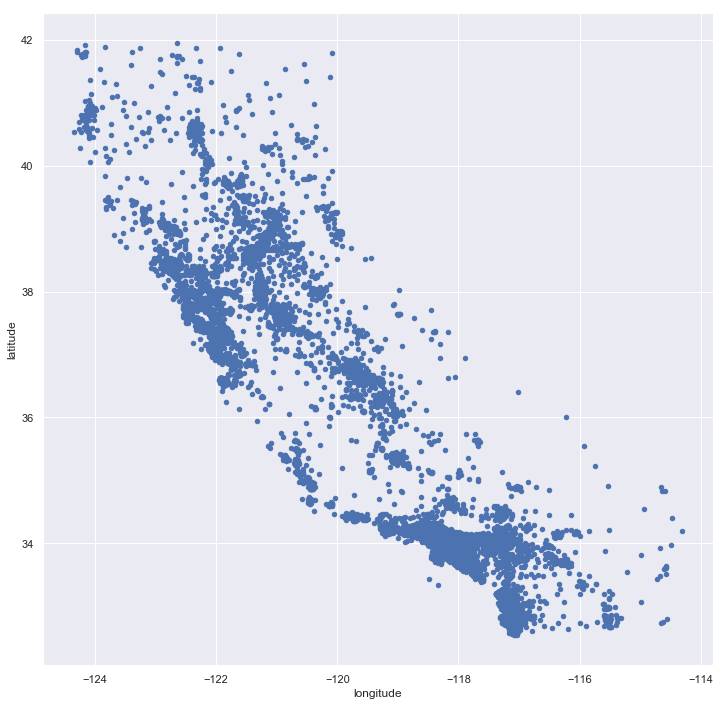

```python
# plotting latitude and longitude
housing.plot(kind='scatter', x='longitude', y='latitude')
```

```
'c' argument looks like a single numeric RGB or RGBA sequence, which should be avoided as value-mapping will have precedence in case its length matches with 'x' & 'y'.  Please use a 2-D array with a single row if you really want to specify the same RGB or RGBA value for all points.
```

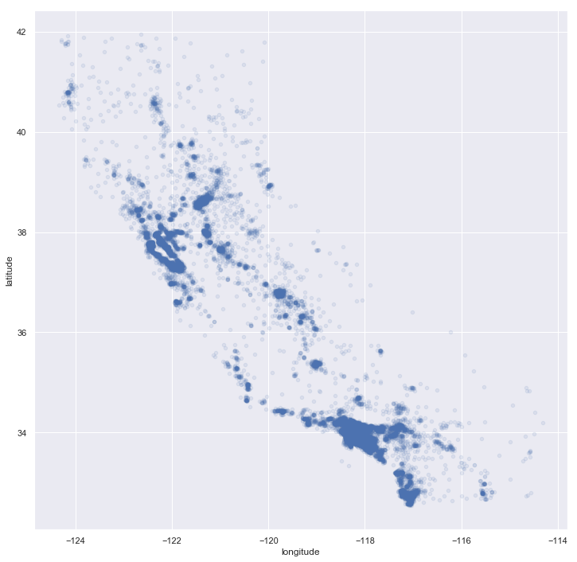

```python
# changing alpha to look at areas of high density
housing.plot(kind='scatter', x='longitude', y='latitude', alpha=0.1)
```

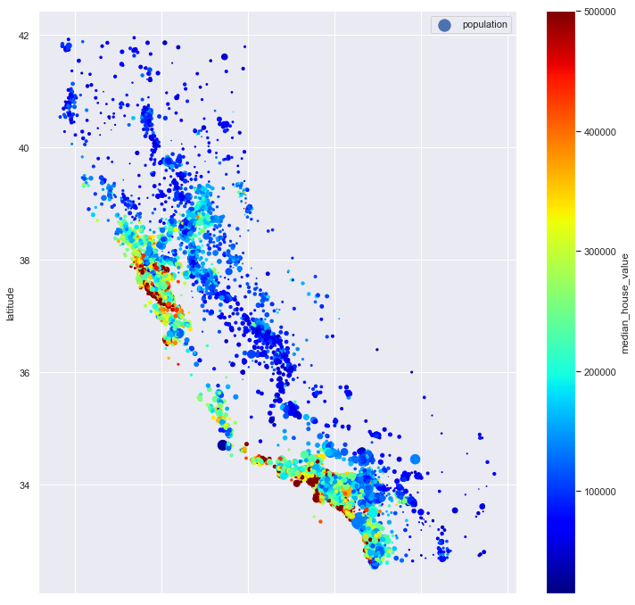

```python
# adding more visualization
# size -> poplulation
# color -> price
housing.plot(kind='scatter',
             x='longitude',
             y='latitude',
             s=housing.population/100,
             label='population',
             c='median_house_value',
             cmap=plt.get_cmap('jet'),
             colorbar=True)
plt.legend()

# Saving the plot
plt.savefig(fig_prefix + "latitude-longitude-median-value.png", dpi=350)
```

## Looking for correlations

```python
# creating a correlation matrix
corr_matrix = housing.corr()
corr_matrix.median_house_value.sort_values(ascending=False)
```

```
median_house_value    1.000000
median_income         0.687160
total_rooms           0.135097
housing_median_age    0.114110
households            0.064506
total_bedrooms        0.047689
population           -0.026920
longitude            -0.047432
latitude             -0.142724
Name: median_house_value, dtype: float64
```

```
array([[<matplotlib.axes._subplots.AxesSubplot object at 0x1a19293b00>,
      dtype=object)
```

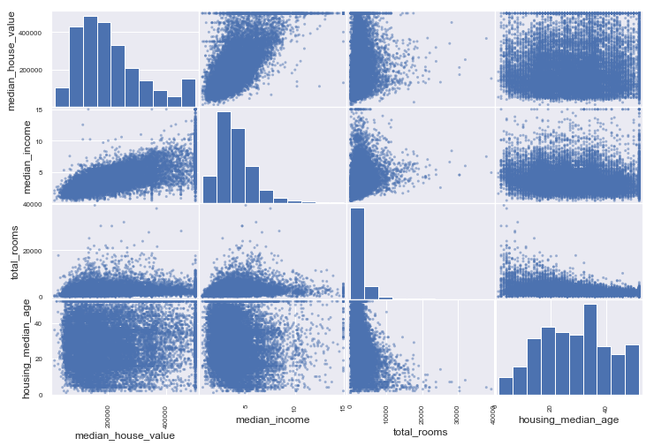

```python
# plotting correlations
# using pandas scatter matrix
attributes = ['median_house_value', 'median_income',
              'total_rooms', 'housing_median_age']
scatter_matrix(housing[attributes],  figsize=(12, 8))
```

```
'c' argument looks like a single numeric RGB or RGBA sequence, which should be avoided as value-mapping will have precedence in case its length matches with 'x' & 'y'.  Please use a 2-D array with a single row if you really want to specify the same RGB or RGBA value for all points.
```

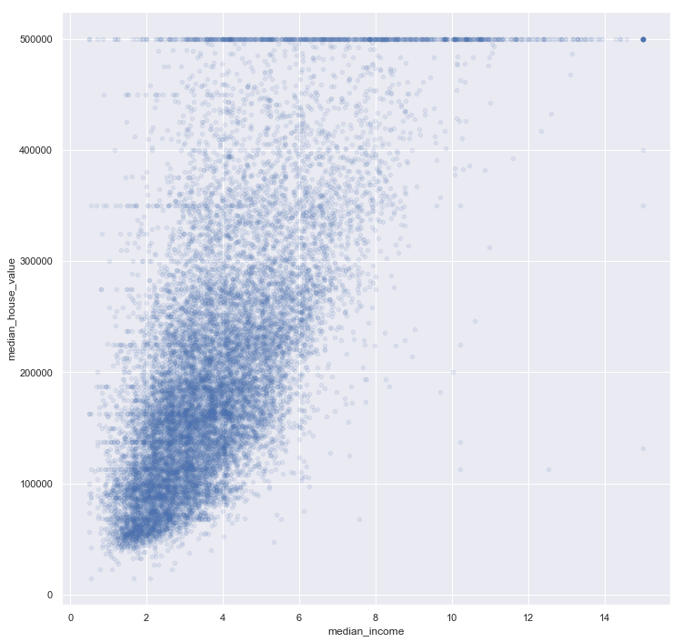

```python
# further investigation for the median income vs the median house value
housing.plot(kind='scatter', x='median_income', y='median_house_value',
             alpha=0.1)
```

### Notes

1. There is a strong correlation between the median house price and the median income.
2. There is a clear horizontal line at \$500,000 because of the cap.
3. There is also few other horizonral lines at \$450,000 \$350,000 \$280,000 and few more. We may need to remove these districts to prevent the algorithm from learning to reproduce these data quirks.

## Attribute combinations

```python
# extracting new attributes
housing['rooms_per_household'] = housing['total_rooms']/housing['households']
housing['bedrooms_per_room'] =  housing['total_bedrooms']/housing['total_rooms']
housing['population_per_household'] = housing['population']/housing['households']
```

```python
# checking correlations
corr_matrix = housing.corr()
corr_matrix['median_house_value'].sort_values(ascending=False)
```

```
median_house_value          1.000000
median_income               0.687160
rooms_per_household         0.146285
total_rooms                 0.135097
housing_median_age          0.114110
households                  0.064506
total_bedrooms              0.047689
population_per_household   -0.021985
population                 -0.026920
longitude                  -0.047432
latitude                   -0.142724
bedrooms_per_room          -0.259984
Name: median_house_value, dtype: float64
```

The new bedrooms_per_room attribute is much more correlated with the median house value than the total number of rooms or bedrooms. Apparently houses with a lower bedroom/room ratio tend to be more expensive. The number of rooms per household is also more informative than the total number of rooms in a district—obviously the larger the houses, the more expensive they are.

# Data cleaning

```python
# splitting the data to predictors and targets
housing = strat_train_set.drop('median_house_value', axis=1)
housing_labels = strat_train_set['median_house_value'].copy()
```

## Getting rid of NaN

### Manually

There are 3 options:

1. Get rid of the corresponding districts. (row)
2. Get rid of the whole attribute. (column)
3. Set the values to some value (zero, mean, median, most common, etc).

option 1

```
housing.dropna(subset=['total_bedrooms'])
```

option 2

```
housing.drop('total_bedrooms', axis=1)
```

option 3

```
median = housing['total_bedrooms'].median()
housing['total_bedrooms'].fillna(median)
```

The median should be stored because the same value will be used for the test set and all new data as well.

### Using sklearn imputer

```python
# initiating an imputer
imputer = Imputer(strategy='median')

# removing categorical fetures
housing_num = housing.drop('ocean_proximity', axis=1)

# fitting the imputer
imputer.fit(housing_num)

# Checing the imputer
imputer.statistics_
```

```
array([-118.51  ,   34.26  ,   29.    , 2119.5   ,  433.    , 1164.    ,
        408.    ,    3.5409])
```

```python
# transforming the numerical features
X = imputer.transform(housing_num)

# putting the data in a dataframe
housing_tr = pd.DataFrame(X, columns=housing_num.columns)
```

## Handling text and categorical attributes

```python
# encoding categorical features
encoder = LabelEncoder()
housing_cat = housing['ocean_proximity']
housing_cat_encoded = encoder.fit_transform(housing_cat)
housing_cat_encoded
```

```
array([0, 0, 4, ..., 1, 0, 3])
```

```python
# using the one hot encoder
encoder = OneHotEncoder()
housing_cat_1hot = encoder.fit_transform(housing_cat_encoded.reshape(-1, 1))
housing_cat_1hot
```

```
<16512x5 sparse matrix of type '<class 'numpy.float64'>'
	with 16512 stored elements in Compressed Sparse Row format>
```

```python
# using the Label Binarizer instead
encoder = LabelBinarizer(sparse_output=True)
housing_cat_1hot = encoder.fit_transform(housing_cat)
housing_cat_1hot
```

```
<16512x5 sparse matrix of type '<class 'numpy.int64'>'
	with 16512 stored elements in Compressed Sparse Row format>
```

## Custom transformers

Although Scikit-Learn provides many useful transformers, you will need to write your own for tasks such as custom cleanup operations or combining specific attributes. You will want your transformer to work seamlessly with Scikit-Learn functionalities (such as pipelines), and since Scikit-Learn relies on duck typing (not inheritance), all you need is to create a class and implement three methods: fit() (returning self), transform(), and fit_transform(). You can get the last one for free by simply adding TransformerMixin as a base class. Also, if you add BaseEstima tor as a base class (and avoid *args and **kargs in your constructor) you will get two extra methods (get_params() and set_params()) that will be useful for automatic hyperparameter tuning. For example, here is a small transformer class that adds the combined attributes we discussed earlier:

```python
from sklearn.base import BaseEstimator, TransformerMixin

rooms_ix, bedrooms_ix, population_ix, household_ix = 3, 4, 5, 6

class CombinedAttributesAdder(BaseEstimator, TransformerMixin):
    def __init__(self, add_bedrooms_per_room = True): # no *args or **kargs
        self.add_bedrooms_per_room = add_bedrooms_per_room

    def fit(self, X, y=None):
        return self # nothing else to do

    def transform(self, X, y=None):
        rooms_per_household = X[:, rooms_ix] / X[:, household_ix]
        population_per_household = X[:, population_ix] / X[:, household_ix]
        if self.add_bedrooms_per_room:
            bedrooms_per_room = X[:, bedrooms_ix] / X[:, rooms_ix]
            return np.c_[X, rooms_per_household,
                         population_per_household, bedrooms_per_room]
        else:
            return np.c_[X, rooms_per_household, population_per_household]
```

```python
# trying the previous class
attr_adder = CombinedAttributesAdder(add_bedrooms_per_room=False)
housing_extra_attributes = attr_adder.transform(housing.values)
housing_extra_attributes
```

```
array([[-121.89, 37.29, 38.0, ..., '<1H OCEAN', 4.625368731563422,
        2.094395280235988],
       [-121.93, 37.05, 14.0, ..., '<1H OCEAN', 6.008849557522124,
        2.7079646017699117],
       [-117.2, 32.77, 31.0, ..., 'NEAR OCEAN', 4.225108225108225,
        2.0259740259740258],
       ...,
       [-116.4, 34.09, 9.0, ..., 'INLAND', 6.34640522875817,
        2.742483660130719],
       [-118.01, 33.82, 31.0, ..., '<1H OCEAN', 5.50561797752809,
        3.808988764044944],
       [-122.45, 37.77, 52.0, ..., 'NEAR BAY', 4.843505477308295,
        1.9859154929577465]], dtype=object)
```

# Transformation piplines

```python
from sklearn.base import BaseEstimator, TransformerMixin

class DataFrameSelector(BaseEstimator, TransformerMixin):
    def __init__(self, attribute_names):
        self.attribute_names=attribute_names
    def fit(self, X, y=None):
        return self
    def transform(self, X):
        return X[self.attribute_names].values
```

```python
# Getting lists of numerical and categorical features
num_attribs = list(housing_num)
cat_attribs = ['ocean_proximity']

# Numerical attributes pipeline
num_pipeline = Pipeline([
    ('selector', DataFrameSelector(num_attribs)),
    ('imputer', Imputer(strategy='median')),
    ('attribs_adder', CombinedAttributesAdder()),
    ('std_scaler', StandardScaler()),
])

# Categorical attributes pipeline
cat_pipeline = Pipeline([
    ('selector', DataFrameSelector(cat_attribs)),
    ('label_binarizer', LabelBinarizer()),
])

# Full pipeline
full_pipeline = FeatureUnion(transformer_list=[
    ('num_pipeline', num_pipeline),
    ('cat_pipeline', cat_pipeline),
])
```

```python
# Running the whole pipeline
housing_prepared = full_pipeline.fit_transform(housing)
housing_prepared
```

```
array([[-1.15604281,  0.77194962,  0.74333089, ...,  0.        ,
         0.        ,  0.        ],
       [-1.17602483,  0.6596948 , -1.1653172 , ...,  0.        ,
         0.        ,  0.        ],
       [ 1.18684903, -1.34218285,  0.18664186, ...,  0.        ,
         0.        ,  1.        ],
       ...,
       [ 1.58648943, -0.72478134, -1.56295222, ...,  0.        ,
         0.        ,  0.        ],
       [ 0.78221312, -0.85106801,  0.18664186, ...,  0.        ,
         0.        ,  0.        ],
       [-1.43579109,  0.99645926,  1.85670895, ...,  0.        ,
         1.        ,  0.        ]])
```

# Trying different models

For a list of strings that can be passed to the scoring parameter:

https://scikit-learn.org/stable/modules/model_evaluation.html

```python
# A function to display the scores
def display_scores(scores):
    print('Scores:', scores)
    print('Mean:', scores.mean())
    print('Standard deviation:', scores.std())
```

## Linear regression

```python
lin_reg = LinearRegression()
lin_scores = cross_val_score(lin_reg, housing_prepared, housing_labels, scoring="neg_mean_squared_error", cv=10)
lin_rmse_scores = np.sqrt(-lin_scores)
display_scores(lin_rmse_scores)
```

```
Scores: [66782.73843989 66960.118071   70347.95244419 74739.57052552
 68031.13388938 71193.84183426 64969.63056405 68281.61137997
 71552.91566558 67665.10082067]
Mean: 69052.46136345083
Standard deviation: 2731.6740017983493
```

## Decision tree

```python
tree_reg = DecisionTreeRegressor()
tree_scores = cross_val_score(tree_reg, housing_prepared, housing_labels, scoring="neg_mean_squared_error", cv=10)
tree_rmse_scores = np.sqrt(-tree_scores)
display_scores(tree_rmse_scores)
```

```
Scores: [67479.12219971 67435.51336827 71051.30695849 68939.27148085
 70969.72130008 75416.38317315 71730.79108376 70768.78114608
 76858.7221024  69269.25984577]
Mean: 70991.88726585596
Standard deviation: 2945.567564226327
```

## Random Forest

```python
forest_reg = RandomForestRegressor()
forest_scores = cross_val_score(forest_reg, housing_prepared, housing_labels, scoring="neg_mean_squared_error", cv=10)
forest_rmse_scores = np.sqrt(-forest_scores)
display_scores(forest_rmse_scores)
```

```
Scores: [52209.1467644  50141.82670737 52842.63140555 55052.27379489
 53001.47275319 56601.34328064 49558.77130749 50578.22780671
 55901.29603501 52710.20652054]
Mean: 52859.719637578855
Standard deviation: 2280.627550075705
```

## Pickling the models

```
from sklearn.externals import joblib
joblib.dump(my_model, 'my_model.pkl')
# and later...
my_model = joblib.load('my_model.pkl')
```

# Fine-tune the model

The random forest model seems to be giving the best results. So, I will try to fine-tune that model.

## Grid Search

```python
param_grid = [
    {'n_estimators': [3, 10, 30], 'max_features': [2, 4, 6, 8]},
    {'bootstrap': [False], 'n_estimators': [3, 10], 'max_features': [2, 3, 4]},
]

forest_reg = RandomForestRegressor()
grid_search = GridSearchCV(forest_reg, param_grid, cv=5,
                           scoring='neg_mean_squared_error')

grid_search.fit(housing_prepared, housing_labels)
```

```
GridSearchCV(cv=5, error_score='raise',
       estimator=RandomForestRegressor(bootstrap=True, criterion='mse', max_depth=None,
           max_features='auto', max_leaf_nodes=None,
           min_impurity_split=1e-07, min_samples_leaf=1,
           min_samples_split=2, min_weight_fraction_leaf=0.0,
           n_estimators=10, n_jobs=1, oob_score=False, random_state=None,
           verbose=0, warm_start=False),
       fit_params={}, iid=True, n_jobs=1,
       param_grid=[{'n_estimators': [3, 10, 30], 'max_features': [2, 4, 6, 8]}, {'bootstrap': [False], 'n_estimators': [3, 10], 'max_features': [2, 3, 4]}],
       pre_dispatch='2*n_jobs', refit=True, return_train_score=True,
       scoring='neg_mean_squared_error', verbose=0)
```

```python
# Best params
grid_search.best_params_
```

```
{'max_features': 6, 'n_estimators': 30}
```

**TODO:** Try higher n_estimators since 30 is the best and 30 was the last in that list.

```python
# Best estimator
grid_search.best_estimator_
```

```
RandomForestRegressor(bootstrap=True, criterion='mse', max_depth=None,
           max_features=6, max_leaf_nodes=None, min_impurity_split=1e-07,
           min_samples_leaf=1, min_samples_split=2,
           min_weight_fraction_leaf=0.0, n_estimators=30, n_jobs=1,
           oob_score=False, random_state=None, verbose=0, warm_start=False)
```

```python
# Evaluation scores
cvres = grid_search.cv_results_
for mean_score, params in zip(cvres['mean_test_score'], cvres['params']):
    print(np.sqrt(-mean_score), params)
```

```
64569.47921029206 {'max_features': 2, 'n_estimators': 3}
55198.909167065576 {'max_features': 2, 'n_estimators': 10}
52588.36511513748 {'max_features': 2, 'n_estimators': 30}
61117.82797495058 {'max_features': 4, 'n_estimators': 3}
53162.9141190142 {'max_features': 4, 'n_estimators': 10}
50437.88677789483 {'max_features': 4, 'n_estimators': 30}
59923.50449849253 {'max_features': 6, 'n_estimators': 3}
52517.347132298935 {'max_features': 6, 'n_estimators': 10}
49988.61615068513 {'max_features': 6, 'n_estimators': 30}
58646.26247474585 {'max_features': 8, 'n_estimators': 3}
52244.40644499651 {'max_features': 8, 'n_estimators': 10}
50235.21949551986 {'max_features': 8, 'n_estimators': 30}
62375.8678796297 {'bootstrap': False, 'max_features': 2, 'n_estimators': 3}
54395.258004724776 {'bootstrap': False, 'max_features': 2, 'n_estimators': 10}
59829.22081139899 {'bootstrap': False, 'max_features': 3, 'n_estimators': 3}
52598.10895572356 {'bootstrap': False, 'max_features': 3, 'n_estimators': 10}
58621.224599142144 {'bootstrap': False, 'max_features': 4, 'n_estimators': 3}
51751.4962186039 {'bootstrap': False, 'max_features': 4, 'n_estimators': 10}
```

## Randomized Search

to be tested.

# Analyze best model

```python
# Feature importances
feature_importances = grid_search.best_estimator_.feature_importances_
feature_importances
```

```
array([7.58028541e-02, 6.53579675e-02, 4.10408123e-02, 1.72632853e-02,
       1.68810579e-02, 1.72468433e-02, 1.59709860e-02, 3.25255569e-01,
       4.75584512e-02, 1.08826740e-01, 8.93400265e-02, 4.91188708e-03,
       1.68687870e-01, 6.02108273e-05, 2.15709418e-03, 3.63834429e-03])
```

```python
# Display attributes and their importances
extra_attribs = ['rooms_per_hhold', 'pop_per_hhold', 'bedrooms_per_room']
cat_one_hot_attribs = list(encoder.classes_)
attributes = num_attribs + extra_attribs + cat_one_hot_attribs
sorted(zip(feature_importances, attributes), reverse=True)
```

```
[(0.32525556913394965, 'median_income'),
 (0.1686878701093316, 'INLAND'),
 (0.10882674016620336, 'pop_per_hhold'),
 (0.08934002646309859, 'bedrooms_per_room'),
 (0.07580285414737972, 'longitude'),
 (0.06535796749572359, 'latitude'),
 (0.04755845121560779, 'rooms_per_hhold'),
 (0.04104081226881626, 'housing_median_age'),
 (0.01726328532141379, 'total_rooms'),
 (0.017246843338287132, 'population'),
 (0.016881057945210467, 'total_bedrooms'),
 (0.015970986014222092, 'households'),
 (0.0049118870827466335, '<1H OCEAN'),
 (0.003638344292286553, 'NEAR OCEAN'),
 (0.002157094178469758, 'NEAR BAY'),
 (6.021082725294878e-05, 'ISLAND')]
```

Based on this information, we may need to drop som eless useful features such as 'NEAR OCEAN' and 'NEAR BA'.

We should also look at the specific errors that your system makes, then try to understand why it makes them and what could fix the problem (adding extra features or, on the contrary, getting rid of uninformative ones, cleaning up outliers, etc.).

# Evaluating the model

```python
final_model = grid_search.best_estimator_

X_test = strat_test_set.drop('median_house_value', axis=1)
y_test = strat_test_set['median_house_value'].copy()

X_test_prepared = full_pipeline.transform(X_test)

final_predictions = final_model.predict(X_test_prepared)

final_mse = mean_squared_error(y_test, final_predictions)
final_rmse = np.sqrt(final_mse)

final_rmse
```

```
48043.52999812106
```